# BMS353 Week 5

November 2020

## Week 4 Recap

- normalisation considerations for RNA-seq
- the DESeq2 workflow
- generated a table of potentially-interesting results

## Week 5 Overview

- using annotation databases to help interpret results
- common visualisations for RNA-seq
  - heatmap
  - volcano plot
- customisation of plots

## Annotation

- we often have not very descriptive names in our results table
  - `ENSMG00....`
  - these names are assigned by the resource that defined the transcripts
  - they do not make the results very easy to navigate
- we probably want to include more-common gene names and other genomic information in our tables and plots
- lots of online resources to do this, but not really in the spirit of the course

## Bioconductor resources

- the Bioconductor project provide a number of annotation resources that can help with this task
  - `org.Mm.eg.db`, `org.Hs.eg.db`,…
- they are installed in the usual way with `BiocManager::install`
- downloads a database that can be queried through RStudio
- an alternative is to use the biomart website via the `biomaRt` package

## columns and keys

- given a set of “*keys*” (genes of interest) we want to retrieve a series of *columns* from the database
  - think of the database as one big table
- need to specify what kind of identifier our keys are (e.g. Ensembl ID)
- need to specify the columns we want

## Joining tables

- the table obtained from Bioconductor can be *joined* with your results
  - need to have a column in common (may need to rename one of the tables)

[figure not shown]

## Individual gene plots - sanity checks

- choose your top gene and plot individual sample measurements
- or pick a gene that you know to be up- or down-regulated
- basic plot supported by `DESeq2`, but can be modified using `ggplot2`

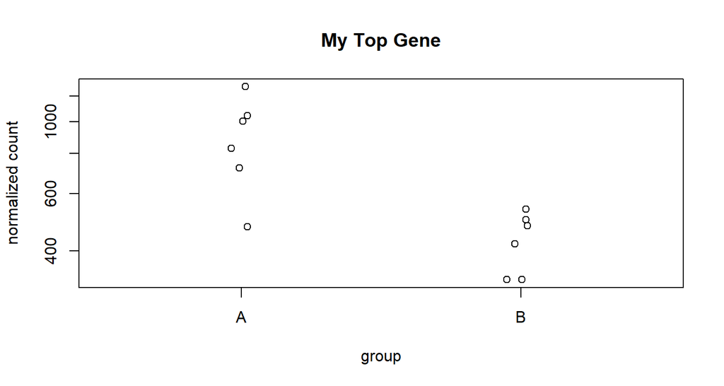

## Volcano plot

- displays significance of result against the magnitude
- can label particular genes of interest

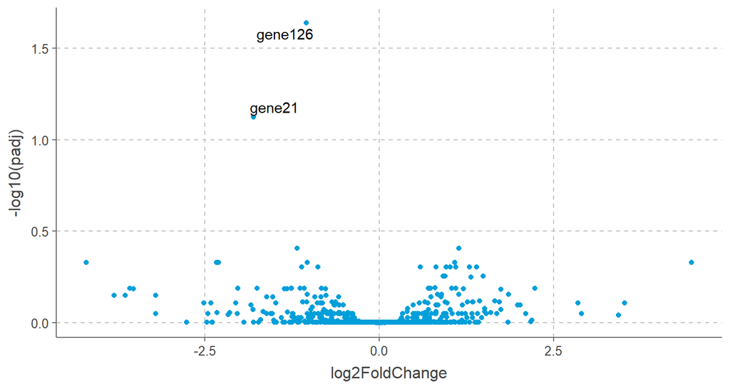

## Heatmaps

- hugely popular visualisation and also highly customisable
- example Van’t veer et al (2002)

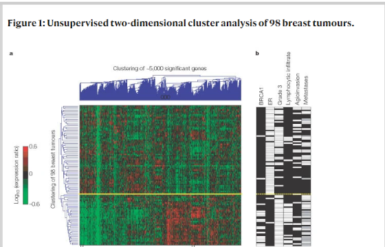

## Heatmaps

- visualise relationships between samples and genes
- a tree-like diagram (dendrogram) shows the relationship between samples and genes
  - derived in an un-supervised way
- can label known sample groups afterwards
- each cell in the plot is coloured according to expression level
  - **please don’t use red and green!**
- actually not that hard to create (one function required), but may take time to create the input data

## Clustering (in brief)

- *distances* are calculated for each combination of samples. i.e. smaller distance meaning samples are similar
- a clustering algorithm the constructs a tree be repeatedly joining samples that are most similar
- the height on the y-axis is used to interpret how similar any two samples are
- however…

## Clustering (in brief)

- the x-axis is somewhat *arbitrary*
- so two samples being adjacent on the x-axis does not imply they are similar
- clustering can never not work

[figure not shown]

## Which genes to include?

- it would be impractical to create the heatmap from *all* genes
  - indeed R would run out of memory
  - and besides, most genes will not be changing or even expressed
- so we can choose an interesting subset
  - e.g. most differentially expressed genes
  - genes from a particular pathway

## Heatmap procedure

- decide on interesting genes to use and get their IDs
- create a *subset* count matrix
  - use the variance-stablised counts
  - the IDs must match the rows of the counts
- use the `pheatmap` function from the `pheatmap` package
- customise as required
- export

## Heatmap results

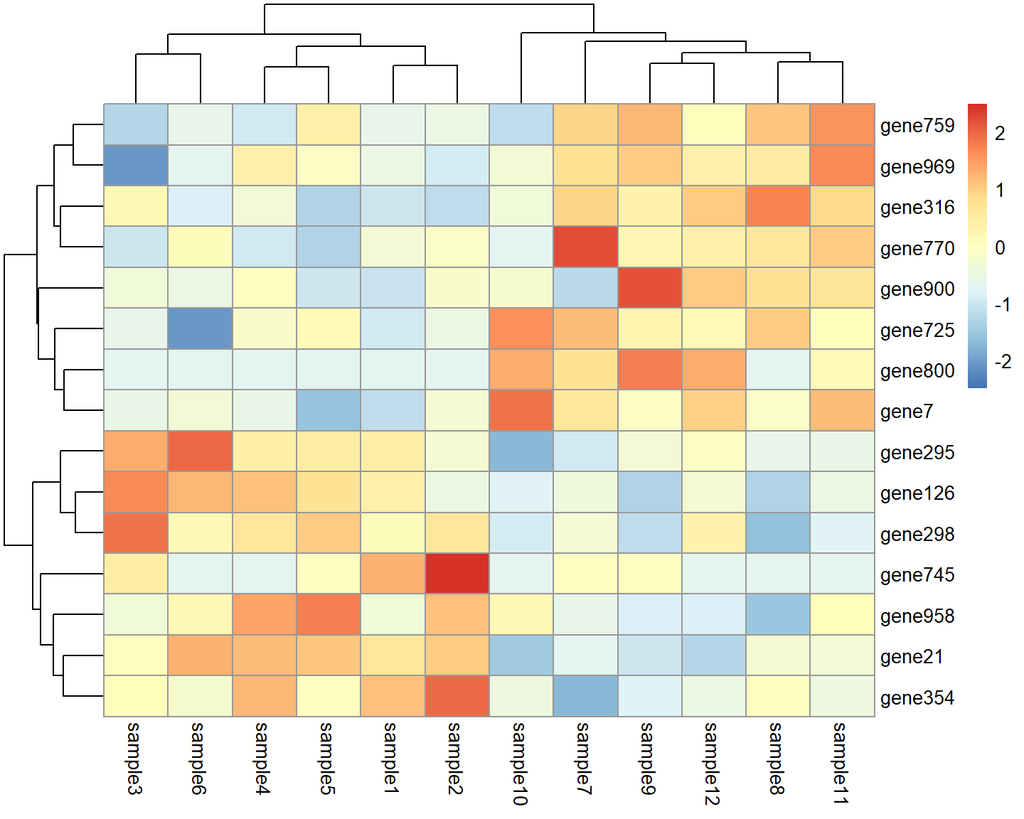

## Further Viewing

- [Drawing and Interpreting Heatmaps](https://youtu.be/oMtDyOn2TCc) - 16 minutes
- [Useful plots and bad plots](https://youtu.be/46-t2jOYsyY) - 17 minutes